# Self-Driving Car Engineer Nanodegree

## Project: Build a Traffic Sign Recognition Classifier

In this notebook, a template is provided for you to implement your functionality in stages which is required to successfully complete this project. If additional code is required that cannot be included in the notebook, be sure that the Python code is successfully imported and included in your submission, if necessary. Sections that begin with **'Implementation'** in the header indicate where you should begin your implementation for your project. Note that some sections of implementation are optional, and will be marked with **'Optional'** in the header.

In addition to implementing code, there will be questions that you must answer which relate to the project and your implementation. Each section where you will answer a question is preceded by a **'Question'** header. Carefully read each question and provide thorough answers in the following text boxes that begin with **'Answer:'**. Your project submission will be evaluated based on your answers to each of the questions and the implementation you provide.

> **Note:** Code and Markdown cells can be executed using the **Shift + Enter** keyboard shortcut. In addition, Markdown cells can be edited by typically double-clicking the cell to enter edit mode.

## Step 0: Load The Data

```python
# Load pickled data
import pickle

# TODO: Fill this in based on where you saved the training and testing data

training_file="./train.p"
testing_file = "./test.p"

with open(training_file, mode='rb') as f:
    train = pickle.load(f)
with open(testing_file, mode='rb') as f:
    test = pickle.load(f)

X_train_in, y_train_in = train['features'], train['labels']
X_test_in, y_test_in = test['features'], test['labels']
```

## Step 1: Dataset Summary & Exploration

The pickled data is a dictionary with 4 key/value pairs:

- `'features'` is a 4D array containing raw pixel data of the traffic sign images, (num examples, width, height, channels).
- `'labels'` is a 2D array containing the label/class id of the traffic sign. The file `signnames.csv` contains id -> name mappings for each id.
- `'sizes'` is a list containing tuples, (width, height) representing the the original width and height the image.
- `'coords'` is a list containing tuples, (x1, y1, x2, y2) representing coordinates of a bounding box around the sign in the image. **THESE COORDINATES ASSUME THE ORIGINAL IMAGE. THE PICKLED DATA CONTAINS RESIZED VERSIONS (32 by 32) OF THESE IMAGES**

Complete the basic data summary below.

```python
### Replace each question mark with the appropriate value.

# TODO: Number of training examples
n_train_in = len(y_train_in)

# TODO: Number of testing examples.
n_test = len(y_test_in)

# TODO: What's the shape of an traffic sign image?
image_shape = train['features'][0].shape

# TODO: How many unique classes/labels there are in the dataset.
n_classes = len(set(y_train_in))

print("Number of training examples =", n_train_in)
print("Number of testing examples =", n_test)
print("Image data shape =", image_shape)
print("Number of classes =", n_classes)
```

```
Number of training examples = 39209
Number of testing examples = 12630
Image data shape = (32, 32, 3)
Number of classes = 43
```

Visualize the German Traffic Signs Dataset using the pickled file(s). This is open ended, suggestions include: plotting traffic sign images, plotting the count of each sign, etc.

The [Matplotlib](http://matplotlib.org/) [examples](http://matplotlib.org/examples/index.html) and [gallery](http://matplotlib.org/gallery.html) pages are a great resource for doing visualizations in Python.

**NOTE:** It's recommended you start with something simple first. If you wish to do more, come back to it after you've completed the rest of the sections.

```
25
```

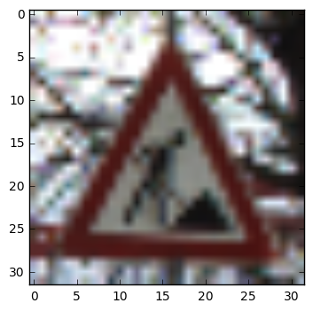

```python
### Data exploration visualization goes here.
### Feel free to use as many code cells as needed.
import matplotlib.pyplot as plt
# Visualizations will be shown in the notebook.
%matplotlib inline

#Visualize Random Training Image from Raw Data
import random
rand_index = random.randint(0,n_train_in)
plt.imshow(X_train_in[rand_index])
print(y_train_in[rand_index])
```

## Step 2: Design and Test a Model Architecture

Design and implement a deep learning model that learns to recognize traffic signs. Train and test your model on the [German Traffic Sign Dataset](http://benchmark.ini.rub.de/?section=gtsrb&subsection=dataset).

There are various aspects to consider when thinking about this problem:

- Neural network architecture
- Play around preprocessing techniques (normalization, rgb to grayscale, etc)
- Number of examples per label (some have more than others).
- Generate fake data.

Here is an example of a [published baseline model on this problem](http://yann.lecun.com/exdb/publis/pdf/sermanet-ijcnn-11.pdf). It's not required to be familiar with the approach used in the paper but, it's good practice to try to read papers like these.

**NOTE:** The LeNet-5 implementation shown in the classroom at the end of the CNN lesson is a solid starting point. You'll have to change the number of classes and possibly the preprocessing, but aside from that it's plug and play!

### Implementation

Use the code cell (or multiple code cells, if necessary) to implement the first step of your project. Once you have completed your implementation and are satisfied with the results, be sure to thoroughly answer the questions that follow.

```python
### Preprocess the data here.
### Feel free to use as many code cells as needed.
```

```python
from SimpleLeNet import transform_image
```

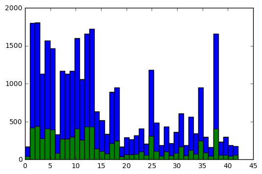

```python
#Plot distribution of the input training data
from sklearn.utils import shuffle
from sklearn.model_selection import train_test_split
X_train_in, y_train_in = shuffle(X_train_in, y_train_in)
#Split training raw training data data into Training and Validation
X_train_raw, X_valid_raw, y_train_raw, y_valid_raw = train_test_split(X_train_in, y_train_in, \
                                                                 test_size=0.2)
#Distribution of Training and Validation Set
plt.hist(y_train_raw,max(y_train_raw)-min(y_train_raw)+1)
print()
plt.hist(y_valid_raw,max(y_valid_raw)-min(y_valid_raw)+1)
print()
```

```python
from SimpleLeNet import AugumentImageData
from SimpleLeNet import LeNet
```

```python
#Define placeholders for Tensorflow

import tensorflow as tf
import numpy as np

x = tf.placeholder(tf.float32, (None, 32, 32, 1))
y = tf.placeholder(tf.int32, (None))
fcdkp= tf.placeholder(tf.float32)
convdkp= tf.placeholder(tf.float32)
#phase_train = tf.placeholder(tf.bool)
to_train= tf.placeholder(tf.bool)
iteration_num= tf.placeholder(tf.int32)
one_hot_y = tf.one_hot(y, 43)

#Define Cross Entropy
rate = 0.001
beta = 0.01
logits = LeNet(x,convdkp,fcdkp)
train_vars   = tf.trainable_variables()
#train_vars   = [conv1_W, conv1_b, conv2_W, conv2_b, fc1_W, fc1_b, fc2_W, fc2_b]
#print(train_vars)
lossL2 = tf.add_n([tf.nn.l2_loss(v) for v in train_vars])*0.0003 #0.0003 is the best
cross_entropy = tf.nn.softmax_cross_entropy_with_logits(logits, one_hot_y)
loss_operation = tf.reduce_mean(cross_entropy)+lossL2 #Regularization
optimizer = tf.train.AdamOptimizer(learning_rate = rate)
training_operation = optimizer.minimize(loss_operation)
predicted_labels = tf.argmax(logits, 1)
true_labels = tf.argmax(one_hot_y, 1)
correct_prediction = tf.equal(predicted_labels, true_labels)
accuracy_operation = tf.reduce_mean(tf.cast(correct_prediction, tf.float32))
loss_value = tf.cast(loss_operation,tf.float32)+lossL2
```

```python
#Preprocess Data
from SimpleLeNet import Preprocess

EPOCHS = 31
BATCH_SIZE = 128

X_train = Preprocess(X_train_raw)
y_train = y_train_raw

X_valid = Preprocess(X_valid_raw)
y_valid = y_valid_raw
```

```python
def GetEvalMetrics(X_data, y_data,batch_fcdkp=1.0,batch_convdkp=1.0,get_labels =False, bn_train = False):
    num_examples = len(X_data)
    #print("Input Dataset: ",num_examples)
    total_accuracy = 0
    total_loss =0

    sess = tf.get_default_session()
    for offset in range(0, num_examples, BATCH_SIZE):
        batch_x, batch_y = X_data[offset:offset+BATCH_SIZE], y_data[offset:offset+BATCH_SIZE]
        mean_loss, accuracy = sess.run([loss_value, accuracy_operation],\
                                       feed_dict={x: batch_x, y: batch_y, fcdkp:batch_fcdkp,convdkp:batch_convdkp
                                                 ,to_train: bn_train})

        total_accuracy += (accuracy * len(batch_x))
        total_loss+= (mean_loss*len(batch_x))

    return total_accuracy / num_examples, total_loss/ num_examples
```

```python
#Train the model
from sklearn.utils import shuffle
from sklearn.model_selection import train_test_split

valid_losses=[None]*EPOCHS
valid_accuracies=[None]*EPOCHS

batch_fcdkp = 0.5
batch_convdkp = 0.7
batch_to_train = True

#tf.reset_default_graph()
with tf.Session() as sess:
    sess.run(tf.global_variables_initializer())
    num_examples = len(X_train)

    print("Training...")
    print()
    for i in range(EPOCHS):
        X_train, y_train = shuffle(X_train, y_train)
        X_valid, y_valid = shuffle(X_valid, y_valid)
        for offset in range(0, num_examples, BATCH_SIZE):
            end = offset + BATCH_SIZE
            batch_x, batch_y = X_train[offset:end], y_train[offset:end]
            sess.run(training_operation, feed_dict={x: batch_x, y: batch_y,fcdkp: batch_fcdkp, convdkp: batch_convdkp\
                   ,to_train:batch_to_train })

        valid_acc,valid_loss = GetEvalMetrics(X_valid,y_valid)
        valid_accuracies[i] = valid_acc
        valid_losses[i] = valid_loss

        if i%10 ==0:
            print("EPOCH {} ... Validation Accuracy={:.3f}".format(i+1,valid_acc))

    try:
        saver
    except NameError:
        saver = tf.train.Saver()
    #saver.save(sess, 'C:/Users/kalyanramu/Documents/CarND-TrafficSignLab')
    saver.save(sess, './trafficsign')
    print("Model saved")
```

```
Training...

EPOCH 1 ... Validation Accuracy=0.532
EPOCH 11 ... Validation Accuracy=0.986
EPOCH 21 ... Validation Accuracy=0.989
EPOCH 31 ... Validation Accuracy=0.987
Model saved
```

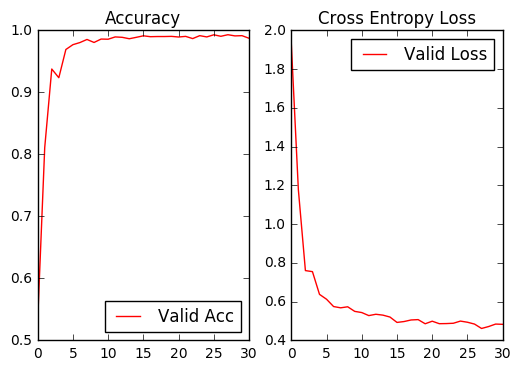

```python
#Plot Training Results

f, axarr = plt.subplots(1,2)
#axarr[0].plot(range(len(train_accuracies)),train_accuracies,'-b',label='Train Acc')
axarr[0].plot(range(len(valid_accuracies)),valid_accuracies,'-r',label='Valid Acc')
axarr[0].set_title("Accuracy")
axarr[0].legend(loc='lower right', shadow=False)

#axarr[1].plot(range(len(train_losses)),train_losses,'-b',label='Train Loss')
axarr[1].plot(range(len(valid_losses)),valid_losses,'-r',label='Valid Loss')
axarr[1].set_title("Cross Entropy Loss")
axarr[1].legend(loc='upper right', shadow=False)
```

```python
X_test = Preprocess(X_test_in)
y_test = y_test_in
```

```python
#Test the model
import tensorflow as tf
with tf.Session() as sess:
    loader = tf.train.import_meta_graph('trafficsign.meta')
    loader.restore(sess, tf.train.latest_checkpoint('.'))
    test_accuracy,test_loss = GetEvalMetrics(X_test,y_test)
    print("Test Accuracy = {:.3f}".format(test_accuracy))
```

```
Test Accuracy = 0.935
```

### Question 1

*Describe how you preprocessed the data. Why did you choose that technique?*

**Answer:**

Preprocessing Steps:

1. Converted the color image into Greyscale Data
2. Normalized the data greyscale data to be between [-0.5,0.5] from [0,255]

As a first step, I converted the images to grayscale. Initially, I trained the network using color images. Network trained using color images had validation accuracy of 98% and test accuracy of 95%. However, when I tried the network on images downloaded from internet, it was perform poorly. It was able to predict 1/6 of images correctly. I realized that the network might not be generalizing enough to predict unknown images. I noticed that the trained model wasn't insensitive enough to brightness variations. When network was trained with Grayscale images, I got similar validation and test accuracy. In addition, the network performed well on images downloaded from internet and it was able classify 5/6 images very well.

Secondly, I normalized the grayscale image from inetensity range[0,255] to between [-0.5, 0.5] to create a well-conditioned problem for the optimizer to converge to a solution.

### Question 2

*Describe how you set up the training, validation and testing data for your model. **Optional**: If you generated additional data, how did you generate the data? Why did you generate the data? What are the differences in the new dataset (with generated data) from the original dataset?*

**Answer:**

Downloaded had two files

- Training File
- Test File. The test file was never used until final verification.

Raw Training Data is divided into two sets

- a) Training Data: Data to train Neural Network
- b) Validation Data: Data to validate the accuracy of Network after an epoch. (20% of the initial training data)

Training Data is divided into batches to train the network. This is done because often times GPU's don't have the memory to accomodate the complete set of training data. Epoch is defined as one run of complete training data (all batches) through feedforward and backprop algorithms.

I generated augumented data initially however I was able to achieve similar accuracy without data augumentation and thus I ended up not using. I didn't delete source as it was good learning experience

### Question 3

*What does your final architecture look like? (Type of model, layers, sizes, connectivity, etc.) For reference on how to build a deep neural network using TensorFlow, see Deep Neural Network in TensorFlow from the classroom.*

**Answer:**

[figure not shown]

As can be seen from the image, the neural network consists of:

- 1 x **Input Layer**
- 6 x **Hidden Layers**
- 1 x **Output Layer**

The table provides a summary of each layer.

[output not shown]

### Question 4

*How did you train your model? (Type of optimizer, batch size, epochs, hyperparameters, etc.)*

**Answer:**

For initialization of weights, truncated normal distribution is used with mean of zero and standard deviation of 0.02.

I have used L2 Regularization along with dropout.

- For convolutional layers dropout of 0.7 was used during training mode (after training, there is no droput).
- For fully connected layers dropout of 0.5 was during training phase (after training, there is no droput).

The table below lists the other hyperparameter values

| Hyperparameter | Value |
| --- | --- |
| `Learning Rate` | `0.001` |
| `Regularization - beta` | `0.0003` |
| `EPOCHS` | `31` |
| `BATCH_SIZE` | `128` |
| `weights - mu` | `0` |
| `weights - sigma` | `0.02` |

### Question 5

*What approach did you take in coming up with a solution to this problem? It may have been a process of trial and error, in which case, outline the steps you took to get to the final solution and why you chose those steps. Perhaps your solution involved an already well known implementation or architecture. In this case, discuss why you think this is suitable for the current problem.*

**Answer:** I tried lot of combinations to come up with the solution. To summarize, here is the approach I took

- a) I increased the size of filters in convolutional layers and number of weights in fully connected layers until the training and validation accuracy got to 99%. In other words, I did overfit the model until I got the training & validation accuracy to 99%
- b) Then I constrained the neural network model using Regularization and dropout until test accuracy increased.

Below is the summary of techniques I tried and learned:

- Data Augumentation
- Add small bias to Relu's to converge faster
- Regularization to contrain the model
- Learning Rate decay to decrease noise in accuracy curves
- Normalization: I used simple normalization here. I did try batch normalization but I couldn't get it working.

## Step 3: Test a Model on New Images

Take several pictures of traffic signs that you find on the web or around you (at least five), and run them through your classifier on your computer to produce example results. The classifier might not recognize some local signs but it could prove interesting nonetheless.

You may find `signnames.csv` useful as it contains mappings from the class id (integer) to the actual sign name.

### Implementation

Use the code cell (or multiple code cells, if necessary) to implement the first step of your project. Once you have completed your implementation and are satisfied with the results, be sure to thoroughly answer the questions that follow.

```python
### Load the images and plot them here.
### Feel free to use as many code cells as needed.

import os
import matplotlib.pyplot as plt
import cv2
import numpy as np
%matplotlib inline

test_images = []
path = './test_images/'
for image in os.listdir(path):
    print(image)
    img = cv2.imread(path + image)
    #print(img.shape)
    #plt.imshow(img)
    img = cv2.resize(img, (32,32),interpolation = cv2.INTER_LINEAR)
    #print(img.shape)
    test_images.append(img)
```

```
stop_sign.jpg
50kph.jpg
30kph.jpg
yield.jpg
no_entry.jpg
120kph.jpg
```

### Question 6

*Choose five candidate images of traffic signs and provide them in the report. Are there any particular qualities of the image(s) that might make classification difficult? It could be helpful to plot the images in the notebook.*

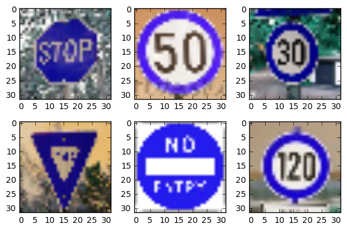

```python
fig = plt.figure()

for i, image in enumerate(test_images):
    grid = plt.subplot(2,3,i+1)
    grid.imshow(image)

plt.tight_layout()
plt.show()
```

**Answer:**

```python
def GetEvalMetricswithLabels(X_data, y_data,batch_fcdkp=1.0,batch_convdkp=1.0,bn_train = False):
    num_examples = len(X_data)
    #print("Input Dataset: ",num_examples)
    total_accuracy = 0.0
    total_loss =0.0
    total_predicted_labels =[]

    sess = tf.get_default_session()
    for offset in range(0, num_examples, BATCH_SIZE):
        batch_x, batch_y = X_data[offset:offset+BATCH_SIZE], y_data[offset:offset+BATCH_SIZE]
        mean_loss, accuracy,out_labels = sess.run([loss_value, accuracy_operation, predicted_labels], \
                                                  feed_dict={x: batch_x, y: batch_y, fcdkp:batch_fcdkp,convdkp:batch_convdkp
                                                            ,to_train: bn_train})
        total_accuracy += (accuracy * len(batch_x))
        total_loss+= (mean_loss*len(batch_x))
        total_predicted_labels.append(out_labels.flatten().tolist())

    return total_accuracy / num_examples, total_loss/ num_examples,total_predicted_labels
```

```python
X_vals = Preprocess(test_images)
y_vals = np.array([14,2,1,13,17,8])

print(X_vals.shape)
print(y_vals.shape)
```

```
(6, 32, 32, 1)
(6,)
```

```python
#images_in = (img_vals-127.5)/255.0
import tensorflow as tf
with tf.Session() as sess:
    loader = tf.train.import_meta_graph('trafficsign.meta')
    loader.restore(sess, tf.train.latest_checkpoint('.'))
    accuracy, loss, labels = GetEvalMetricswithLabels(X_vals, y_vals,batch_fcdkp=1.0,batch_convdkp=1.0)

print("Accuracy: ", accuracy)
print("Correct Labels:",y_vals)
print("Predicted Labels:",labels[0])
```

```
Accuracy:  0.83333337307
Correct Labels: [14  2  1 13 17  8]
Predicted Labels: [14, 1, 1, 13, 17, 8]
```

### Question 7

*Is your model able to perform equally well on captured pictures when compared to testing on the dataset? The simplest way to do this check the accuracy of the predictions. For example, if the model predicted 1 out of 5 signs correctly, it's 20% accurate.*

**NOTE:** You could check the accuracy manually by using `signnames.csv` (same directory). This file has a mapping from the class id (0-42) to the corresponding sign name. So, you could take the class id the model outputs, lookup the name in `signnames.csv` and see if it matches the sign from the image.

```python
#images_in = (img_vals-127.5)/255.0
import tensorflow as tf
with tf.Session() as sess:
    loader = tf.train.import_meta_graph('trafficsign.meta')
    loader.restore(sess, tf.train.latest_checkpoint('.'))
    accuracy, loss, labels = GetEvalMetricswithLabels(X_vals, y_vals,batch_fcdkp=1.0,batch_convdkp=1.0)

print("Accuracy: ", accuracy)
print("Correct Labels:",y_vals)
print("Predicted Labels:",labels[0])
```

```
Accuracy:  0.83333337307
Correct Labels: [14  2  1 13 17  8]
Predicted Labels: [14, 1, 1, 13, 17, 8]
```

**Answer:** The solution had accuracy of 83.33% on 6 images which is pretty good for mall data set.

### Question 8

*Use the model's softmax probabilities to visualize the **certainty** of its predictions, [`tf.nn.top_k`](https://www.tensorflow.org/versions/r0.12/api_docs/python/nn.html#top_k) could prove helpful here. Which predictions is the model certain of? Uncertain? If the model was incorrect in its initial prediction, does the correct prediction appear in the top k? (k should be 5 at most)*

`tf.nn.top_k` will return the values and indices (class ids) of the top k predictions. So if k=3, for each sign, it'll return the 3 largest probabilities (out of a possible 43) and the correspoding class ids.

Take this numpy array as an example:

```
# (5, 6) array
a = np.array([[ 0.24879643,  0.07032244,  0.12641572,  0.34763842,  0.07893497,
         0.12789202],
       [ 0.28086119,  0.27569815,  0.08594638,  0.0178669 ,  0.18063401,
         0.15899337],
       [ 0.26076848,  0.23664738,  0.08020603,  0.07001922,  0.1134371 ,
         0.23892179],
       [ 0.11943333,  0.29198961,  0.02605103,  0.26234032,  0.1351348 ,
         0.16505091],
       [ 0.09561176,  0.34396535,  0.0643941 ,  0.16240774,  0.24206137,
         0.09155967]])
```

Running it through `sess.run(tf.nn.top_k(tf.constant(a), k=3))` produces:

```
TopKV2(values=array([[ 0.34763842,  0.24879643,  0.12789202],
       [ 0.28086119,  0.27569815,  0.18063401],
       [ 0.26076848,  0.23892179,  0.23664738],
       [ 0.29198961,  0.26234032,  0.16505091],
       [ 0.34396535,  0.24206137,  0.16240774]]), indices=array([[3, 0, 5],
       [0, 1, 4],
       [0, 5, 1],
       [1, 3, 5],
       [1, 4, 3]], dtype=int32))
```

Looking just at the first row we get `[ 0.34763842, 0.24879643, 0.12789202]`, you can confirm these are the 3 largest probabilities in `a`. You'll also notice `[3, 0, 5]` are the corresponding indices.

```python
import pandas as pd
categories = pd.read_csv('signnames.csv')
cat_names=categories['SignName']
```

```python
def vis_softmax(tf_model,input_img,top_nprobs = 3, category_names =None):
    import matplotlib.pyplot as plt
    import pandas as pd
    #Import the model
    if tf_model == None:
        print("Error: Empty Model")
        return
    with tf.Session() as sess:
        loader = tf.train.import_meta_graph(tf_model)
        loader.restore(sess, tf.train.latest_checkpoint('.'))

    #Get softmax probabilities
        feed_vals ={x:input_img, fcdkp:1.0,convdkp:1.0,to_train:0}
        score_vals,label_nums = sess.run(tf.nn.top_k(tf.nn.softmax(logits),k=top_nprobs), feed_dict= feed_vals)
        scores = score_vals[0]
        scores_labels = label_nums[0]

    #Build Pandas Dataframe for output
        fig = plt.figure(figsize=(11,7))
        #fig = plt.figure()
        grid = plt.subplot(1,2,1)
        image = np.array(input_img)[0,:,:,0]
        plt.imshow(image,cmap='gray')

        grid = plt.subplot(1,2,2)
        plt.ylabel('Categories')
        plt.xlabel('Probabilities')
        y_pos = list(range(top_nprobs))
        if len(category_names)>0:
            label_names = [category_names[i] for i in scores_labels] #Get names of top 5 labels
        plt.yticks(y_pos,label_names)
        plt.barh(y_pos,scores,align='center')
        plt.tight_layout()
        df = pd.DataFrame(scores, index = label_names, columns =['Probability'])
    return df
```

```python
from IPython.display import display, HTML
```

|  | Probability |
| --- | --- |
| Speed limit (30km/h) | 9.999894e-01 |
| Speed limit (70km/h) | 6.237672e-06 |
| Road narrows on the right | 1.769104e-06 |
| Speed limit (50km/h) | 6.296756e-07 |
| Keep left | 6.071091e-07 |

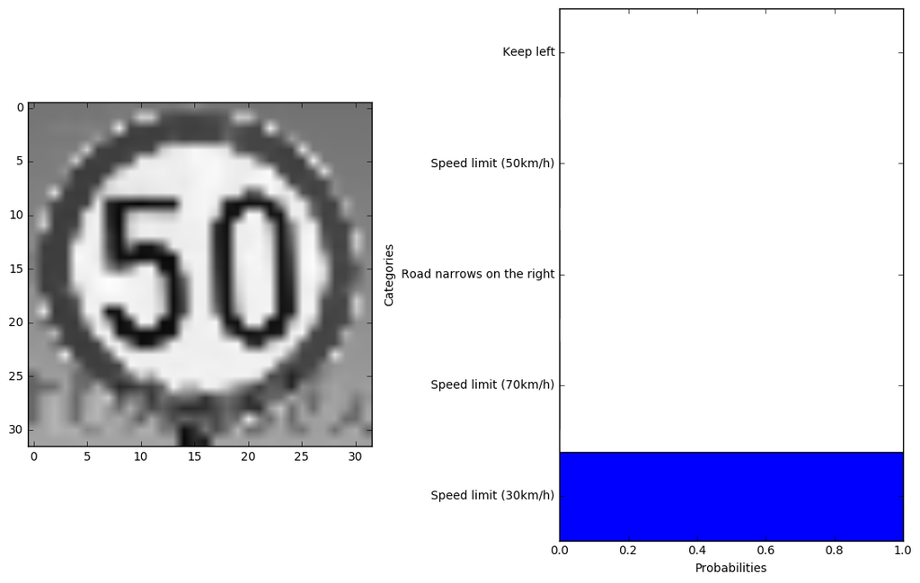

```python
df = vis_softmax('trafficsign.meta',[X_vals[1]],top_nprobs =5, category_names = cat_names)
display(df)
```

Eventhough the image was misclassified as 30km/h, the correct choice is in top 5 candidates. As we can see, the model very confident that this is a 30km/h sign. Fortunately, the correct answer is in top 5 candidates, hinting that the model may perform better on different images of 50km/h signs. This is where data augumentation could probably have helped the classification. For the remaining images in the googled test set, the model is nearly 100% confident in it's predictions.

|  | Probability |
| --- | --- |
| Stop | 0.991328 |
| Turn right ahead | 0.002129 |
| No entry | 0.001829 |
| Turn left ahead | 0.001631 |
| Road work | 0.001208 |

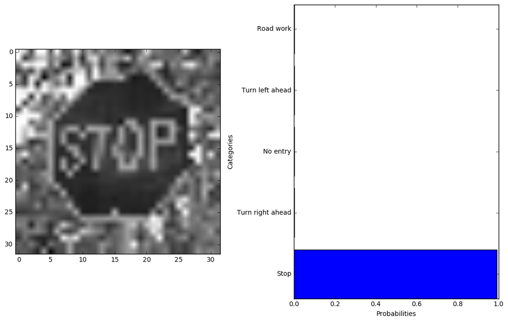

```python
df = vis_softmax('trafficsign.meta',[X_vals[0]],top_nprobs =5, category_names = cat_names)
display(df)
```

|  | Probability |
| --- | --- |
| Speed limit (30km/h) | 0.990962 |
| Speed limit (50km/h) | 0.002241 |
| Speed limit (20km/h) | 0.001683 |
| Speed limit (100km/h) | 0.000886 |
| Speed limit (70km/h) | 0.000845 |

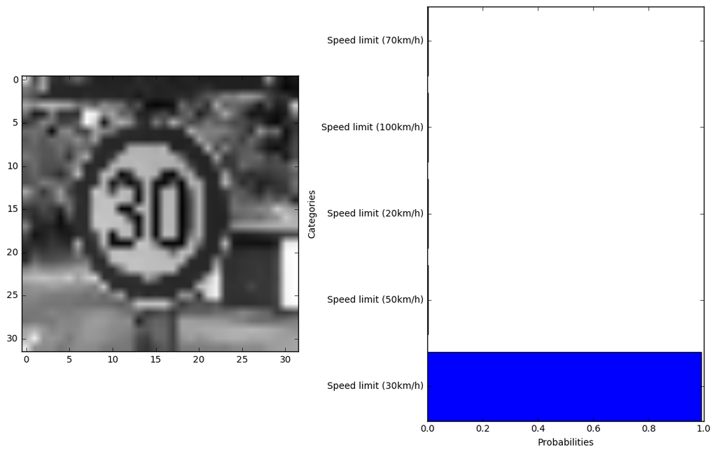

```python
df = vis_softmax('trafficsign.meta',[X_vals[2]],top_nprobs =5, category_names = cat_names)
display(df)
```

|  | Probability |
| --- | --- |
| Yield | 0.995833 |
| Keep left | 0.002069 |
| Ahead only | 0.000813 |
| Turn right ahead | 0.000347 |
| Stop | 0.000112 |

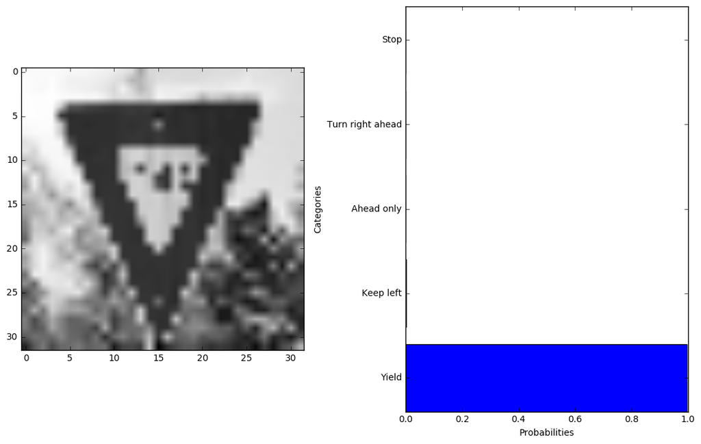

```python
df = vis_softmax('trafficsign.meta',[X_vals[3]],top_nprobs =5, category_names = cat_names)
display(df)
```

|  | Probability |
| --- | --- |
| No entry | 0.996252 |
| Turn right ahead | 0.001527 |
| Go straight or left | 0.000520 |
| Priority road | 0.000472 |
| No passing | 0.000346 |

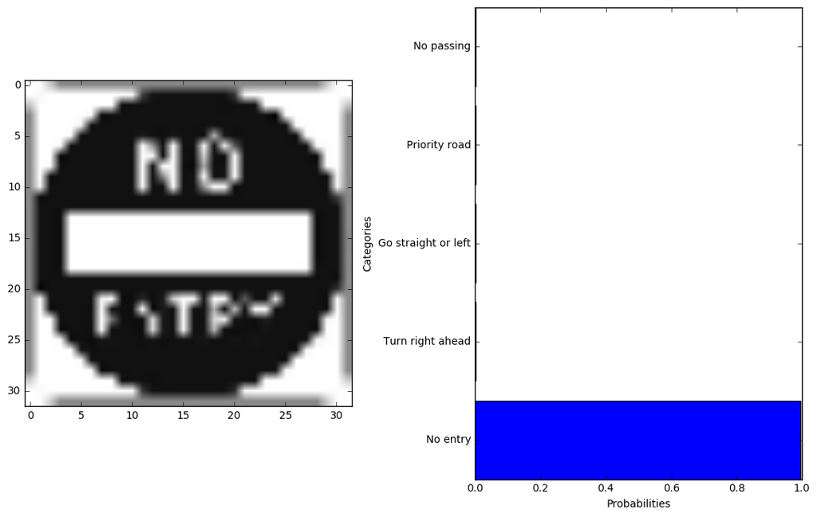

```python
df = vis_softmax('trafficsign.meta',[X_vals[4]],top_nprobs =5, category_names = cat_names)
display(df)
```

|  | Probability |
| --- | --- |
| Speed limit (120km/h) | 0.961812 |
| Speed limit (100km/h) | 0.037313 |
| Roundabout mandatory | 0.000573 |
| Speed limit (80km/h) | 0.000166 |
| Speed limit (70km/h) | 0.000035 |

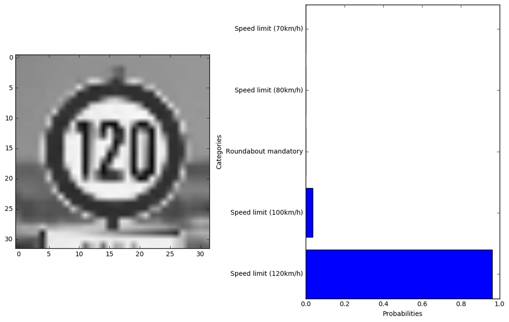

```python
df = vis_softmax('trafficsign.meta',[X_vals[5]],top_nprobs =5, category_names = cat_names)
display(df)
```